# Coursework Report

*N* removed NAs: 2

*N* removed typo: 1

*N* removed <18: 30

*N* total clean: 117

| Group | *N* | *M*<sub>age</sub> | *M*<sub>rating</sub> |
| --- | --- | --- | --- |
| Control | 61 | 20.7 | 5.86 |
| Experim | 56 | 20.6 | 6.72 |

**Main analysis results**

*t*(115) = -5.65, *p* < .001

[interactive chart not shown]

[figure not shown]

[interactive chart not shown]

# Coursework Report

Analysing Data, Spring 2020

# Methods

## Participants

The experiment initially consisted of 150 participants. However, 2 participants have been removed due to missing data. A further participant was removed for incorrectly filled out data, leaving a remainder of 147 participants. Another 30 participants were removed for being under 18 years of age which is an unethical age of participation. Therefore the final number of participants whose data are included in the results are 117 (*M*<sub>years</sub> =20.68, *SD*<sub>years</sub> = 2.19, *range*<sub>years</sub> = 11). Figure 1 shows the participants years of age by condition.

Figure 1. The participants years of age descriptive by condition.

| Condition | *N* | % | *M*<sub>years</sub> | *SD*<sub>years</sub> |
| --- | --- | --- | --- | --- |
| control | 61 | 52.1 | 20.7 | 2.29 |
| experimental | 56 | 47.9 | 20.6 | 2.10 |

## Design

The conceptual hypothesis that the research investigated was, does the colour red have an effect on attraction? The independent variable was colour. Participants were given a picture of a male to view, this photo was presented with either a red or white border, this was the operationalisation of colour. The white border was used as a control condition. The red border was the experimental condition. The dependent variable was perceived attractiveness, this was operationalised by using ratings on a scale of 1-9, in response to three questions. The questions have been created and utilised by Elliot *et al*.,(2010). The first question was “How attractive do you think this person is?”. The next question was “How pleasant is this person to look at?”. The final question was “If I were to meet the person in this picture face to face, I would think he is attractive”. The values on the rating scale ranged from 1, which represents ‘not at all attractive’ to the highest value 9, that represents ‘extremely attractive’; hence the higher the rating the greater the perceived attraction. The rating responses given were then averaged to obtain a composite score. Hence, the operational hypothesis is, if seeing a red or white border around a photo of a man considered moderately attractive has an impact on the mean attractiveness rating for him. The statistical analysis that will be used to test this operational hypothesis is the independent- measures *t*- test.

# Results

The data was transformed by averaging the rating scores given by the participants on the three different questions to produce a composite score. The mean attractiveness rating was higher in the red condition (*M* = 6.72, *SD* = 0.85) than in the white condition (*M* = 5.86, *SD* = 0.79) (Figure 2). This shows that participants in the experimental, red condition found the man more attractive than those in the control, white condition. This difference was significant (*M*`<sub>diff</sub> = -0.86, 95% CI [-1.16,-0.56], *t* (115) = -5.65, *p* < .001).

The independent measures *t*- test used for the analysis, carries out a comparison between the difference in means with the standard deviation of the difference in means to produce the test statistic *t*. The value of *t* generated is -5.65, the mean difference of -0.86 is 5.65 times greater than the standard error of the difference in the sample means. The probability of obtaining a value of *t* equal to or bigger than -5.65 is < .001. As this probability is very small, it is unlikely that the two sample means are from the same population. The manipulation of the conditions produced two different populations, these are; ‘people who saw the image of the man in a red border’ and ‘people who saw the image of the man in a white border’. The null hypothesis was that the true difference in the sample means is 0, however the analysis shows this is not true. Therefore, we reject the null hypothesis. Hence, the analysis results suggest that whether a participant views a red or white border around the image of a man does influence attractiveness ratings.

Figure 2 The mean attractiveness rating in the colour conditions.

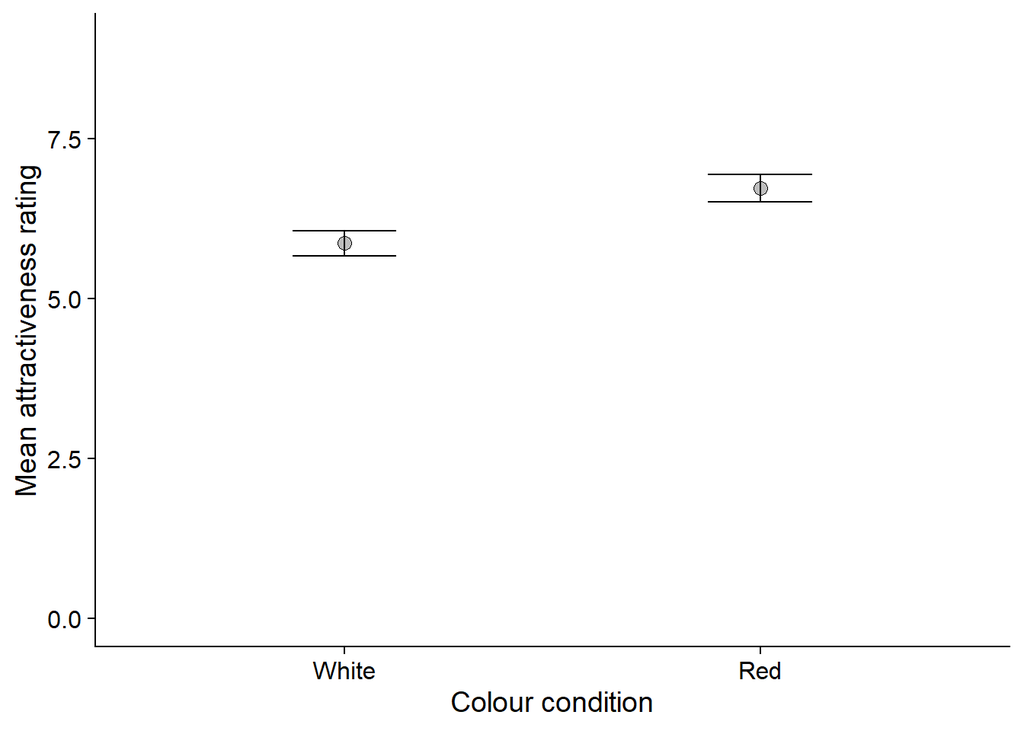

# Discussion

The research began with a simple question: Does the colour red influence attraction? In order to answer this question, the present research expanded the question to: Does the red colour of a photographs border make a difference to the way individuals perceive attractiveness? The analysis of the results demonstrates that people perceive a moderately attractive man in a photograph to be more attractive when the photograph has a red border than when the border around the photograph is white. The answer that these findings supplies to the research question is that, red does indeed have an effect on attraction.

This research experiment was a replication of ‘Experiment 1’ carried out in Elliot *et al*.,(2010) series of experiments examining the impact of colour. The stimulus material as well as the operationalisation of the variables, was identical. The findings of the present research confirm those of Elliot *et al*.,(2010) that is, viewing a red frame around the image of a man means that he is considered of greater attractiveness (attains a higher mean rating of attractiveness) than when his image is surrounded with a white border. In addition to this, Roberts, Owen, and Havlicek’s, (2010) findings also show a similar pattern of results, that is, women give a higher rating of attractiveness to men in red shirts. Furthermore, Elliot & Niesta, (2008) results depicted that men give a higher attractiveness rating to a woman when her photograph has a red frame as compared to a white frame. These similar findings contribute to the answer of the research question, providing evidence that the colour red does influence attraction.

However, Hesslinger, Goldbach, & Carbon, (2015) also replicated Elliot *et al*., (2010), but unlike the present research study, they did not obtain a statistically significant effect of red on perceived attraction. This may have been because the present study and the Elliot *et al*., (2010) study was carried out with participants living in the United States whereas Hesslinger, Goldbach, & Carbon, (2015) study was conducted in Germany. Perceptions based on the colour red are based on the cultural meanings and associations of red. A limitation of the Elliot *et al*.,(2010) study and its replications, including the present study is that it does not have a test of colour meanings. In Germany, red has been found to have significant associations with the concepts, ‘upset’, ‘false’ and ‘dangerous’ (Griber, Jung & Weber, 2018). On the other hand, in the U.S.A, there is a strong connection of red to love (Jacobs, Keown, Worthley, & Gyhmn, 1991). Therefore, as red has a strong affiliation with romantic feelings in the U.S.A, in comparison to the negative associations of red in Germany, it is possible that the meaning red holds is the reason for the differences in the results obtained. To test this suggestion further replications should be conducted in Germany and U.S.A, with a test at the end on colour associations; specifically asking about concepts that the participant affiliates with red. This will allow a comparison to observe if this effect is due to the meaning red holds or because red does not influence perceived affection.

Schwarz & Singer, (2013) showed men photos of young and old women against a red or white background and then asked them to give the women a sexually and physically attractive rating. The questions asked to measure physical attraction were similar to those asked to measure perceived attraction in the present study e.g. “How beautiful do you think this person is?”, so physical and perceived attraction can be considered the same. They found a significant effect of red on sexual attractiveness but did not find a significant effect of red on physical attractiveness. These results contradict those found in the present study. The cause of this may be due to the difference in the study design. Schwarz & Singer, (2013) asked their participants to rate the photographs on four measures: sexual attractiveness, physical attractiveness, intelligence and likeability. A limitation of the present study is that it did not operationalise attraction to the same extent. It is possible that in the present study the participants subconsciously rated the man based on their sexual attraction to him as well, as there were no separate questions on this, this was not measured. If a separate set of questions on sexual attractiveness were also present, a similar effect to Schwarz & Singer, (2013) may have been observed. However, we cannot be certain of this possibility. As a result, future research should be conducted with attraction operationalised separately for perceived sexual attraction and perceived physical attraction aimed at discovering whether a red frame effects all perceptions of attraction.

Similarly, Seibt’s, (2015) findings demonstrated that a red background against a picture of an individual does not have an impact on the perceived attraction towards that individual. This pattern of results do not support those produced by the present study. This may be a result of the Seibt, (2015) study measuring perceived attractiveness by simply asking participants to give an attractiveness rating to the target in the image on a 5- point Likert scale. In comparison, participants in the present study were asked to rate the picture of the man on a 9- point scale in response to three separate questions, each assessing perceived attractiveness. This is a strength of the present study as it produces 3 different attractiveness ratings from which a mean value can be calculated. In Seibt’s, (2015) study it is possible that participants give random ratings without much thought as, unlike in the present study, there are no questions that force them to consider their attraction towards the targets photo. Therefore, the present study has greater validity than the Seibt, (2015) study as there is greater likelihood that the ratings are a result of attraction.

The consequence of these studies that reveal a pattern different from that observed in the present study is that the research question does not have a clear, direct answer. Hence, further research is required in this area to determine if red does affect attraction.

A further limitation of the present study is that it investigates whether red influences perceived attraction by asking participants questions. The ratings given in response to the questions are likely to be caused by many extraneous factors as well, these include mood and lying. This can reduce the validity of the study and so the extent to which it can provide an answer to the research question. Future studies may consider the use of a different method of measuring attraction to avoid this problem. A suggestion is to collect heart rate readings as it has been found that viewing someone, we perceive to be attractive, causes an increase in adrenaline, and so in heart rate (McKinney, 2011). Alternatively, the duration the participant spends looking at the target image in the different coloured frames can be measured, as research with female primates has revealed we observe what we consider attractive for a longer duration of time (Waitt *et al*., 2003).

To summarise, the research question was, whether the colour red has an impact on the perceived attraction of individuals. The results of the present study show that it does, this is as, participants gave a higher mean attractiveness rating to a moderately attractive man’s photo when it was surrounded with a red border than a white border. This difference was found to be significant. The main implication of this is that it provides an answer to the research question. This answer is that red does influence attraction. The next step is to carry out further research using different forms of operationalisation of the variables e.g. red shirt, red makeup and using heart rate measurements. This will allow a larger perspective to be gained on whether red does affect attractiveness.

# References

Elliot, A. J., & Niesta, D. (2008). Romantic red: Red enhances men’s attraction to women. Journal of Personality and Social Psychology, 95(5), 1150–1164.

Elliot, A. J., Kayser, D. N., Greitemeyer, T., Lichtenfeld, S., Gramzow, R. H., Maier, M. A., & Liu, H. (2010). Red, rank, and romance in women viewing men. Journal of Experimental Psychology: General, 139(3), 399–417.

Griber, Yulia & Weber, Ralf & Jung, Ivar. (2018). Color associations: Germany as a case study. 4. 2611.

Hesslinger, V.M., Goldbach, L. & Carbon, C. (2015). Men in red: A reexamination of the red-attractiveness effect. Psychon Bull Rev 22, 1142–1148.

McKinney K. (2011) The Effects of Adrenaline on Arousal and Attraction. Scholars: McKendree University Online Journal of Undergraduate Research. 17.

Roberts, S.C., Owen, R.C., & Havlíček, J. (2010). Distinguishing between perceiver and wearer effects in clothing color-associated attributions. Evolutionary psychology : an international journal of evolutionary approaches to psychology and behavior, 8 3, 350-64.

Schwarz, S., & Singer, M. (2013). Romantic red revisited: Red enhances men’s attraction to young, but not menopausal women. Journal of Experimental Social Psychology, 49(1), 161–164.

Seibt, T. (2015). Romantic red effect in the attractiveness perception. In Proceedings of the Human and Social Sciences at the Common Conference (Vol. 3, No. 1, pp. 31-34).

Waitt, C., Little, A. C., Wolfensohn, S., Honess, P., Brown, A. P., BuchananSmith, H. M., & Perrett, D. I. (2003). Evidence from rhesus macaques suggests male coloration plays a role in female primate mate choice. Proceedings of the Royal Society, Series B, 270(Suppl.), 144 –146.